**INTRODUCTION TO ARTIFICIAL INTELLIGENCE**  
Academiejaar 2021-2022  
Stefaan Haspeslagh  
Andy Louwyck  
Pieter Ideler

# Maze: DFS en BFS

## Inleiding

Het doolhofprobleem is een veel gebruikt probleem om zoekalgoritmen op uit te testen. Een doolhof is een rooster met n x n vakken. Een vak kan een barrière bevatten, dit zijn vakjes waarop niet kan 'gewandeld' worden. De uitdaging is om, gegeven een startpositie (links onder in het voorbeeld), een pad naar het doel te vinden (rechts boven in het voorbeeld). Mogelijke richtingen waarin gewandeld kan worden (in die volgorde!) zijn: links, rechts, naar boven en naar onder. Diagonaal kan er niet gewandeld worden.

In deze notebook implementeren we het diepte-eerst- en breedte-eerst-algoritme, in het Engels Depth-First Search (DFS) en Breadth-First Search (BFS). We maken hierbij gebruik van de state-space en de production rules voor het doolhofprobleem die we in het vorige topic hebben uitgewerkt.

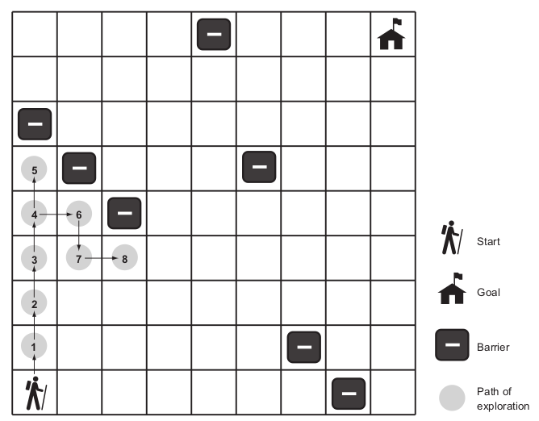

## State-Space Representation

We hebben een generiek OO-model geïmplementeerd waarin de volgende concepten een plaats kregen:

- **state**: een klasse waar de toestand van het zoekprobleem kan weergeven. Op een toestand moet je een move kunnen toepassen om naar een andere toestand te gaan.
- **goal**: van een bepaalde state moet je kunnen evalueren of die de goaltoestand is of niet.
- **move**: een move bepaalt hoe je van de ene naar de andere toestand kan overgaan

De OO-structuur biedt een generiek kader waarin we verschillende zoekproblemen kunnen formuleren.

```python
# eerst importeren we de nodige Python packages, modules, klassen en functies
from abc import ABC, abstractmethod
from IPython.display import clear_output
from time import sleep
import numpy as np
import matplotlib.pyplot as plt
from matplotlib import colors
```

```python
class State(ABC):

    @abstractmethod
    def calculate_moves(self):
        # Op een state wordt deze methode aangeroepen om volgens de production rules
        # de moves te berekenen die het probleem in een nieuwe toestand kunnen brengen.
        # Deze functie geeft dus een lijst van moves terug (eventueel leeg).
        pass

    @abstractmethod
    def apply_move(self, move):
        # Op een state kan een move toegepast worden om naar een volgende state over te gaan.
        # Deze functie geeft dus een nieuwe state terug.
        pass

    @abstractmethod
    def is_goal(self):
        # Controleert of een state de `goal state` is.
        # Retourneert dus een booleaanse waarde.
        pass
```

```python
class Move:

    def __init__(self, state):
        self.state = state

    def apply(self):
        return self.state.apply_move(self)
```

Daarna hebben we overerving toegepast om ons specifieke doolhofprobleem te implementeren.

De toestand of **state** hebben we gedefinieerd a.d.h.v.:

- de *positie* wat het vakje is waar we staan;
- de *configuratie* van het doolhof;
- het *pad* dat we al hebben afgelegd.

Onderstaande klassen implementeren deze concepten.

```python
class Position:

    def __init__(self, irow, icol):
        self.irow = irow
        self.icol = icol

    def __eq__(self, other):
        return self.irow == other.irow and self.icol == other.icol

    def __repr__(self):
        return "({}, {})".format(self.irow, self.icol)
```

```python
class Path:

    def __init__(self, *positions):
        self.positions = positions

    @property
    def length(self):
        return len(self.positions)

    @property
    def irow(self):
        return np.array([position.irow for position in self.positions])

    @property
    def icol(self):
        return np.array([position.icol for position in self.positions])

    def contains(self, position):
        return position in self.positions

    def add(self, position):
        return Path(*self.positions, position)

    def __repr__(self):
        positions = ", ".join([str(position) for position in self.positions])
        return f"[{positions}]"
```

```python
class Maze:

    symbols = ('*', '.', '#', 'o')

    def __init__(self, grid):
        # grid is integer array:
        # start = 0, free = 1, wall = 2, goal = 3
        self.grid = np.array(grid)
        self.size = self.grid.shape[0]

    def get_start(self):
        irow, icol = np.where(self.grid == 0)
        return Position(irow[0], icol[0])

    def get_goal(self):
        irow, icol = np.where(self.grid == 3)
        return Position(irow[0], icol[0])

    def is_valid(self, position):
        # checkt of een positie geldig is: moet binnen het grid liggen en mag geen barrière zijn
        return (0 <= position.irow < self.size and
                0 <= position.icol < self.size and
                self.grid[position.irow, position.icol] != 2)

    def plot(self):
        # colormap
        cmap = colors.ListedColormap(['forestgreen', 'lightyellow', 'purple', 'red'])
        bounds = np.linspace(-0.5, 3.5, 5)
        norm = colors.BoundaryNorm(bounds, cmap.N)
        # plot grid
        plt.matshow(self.grid, cmap=cmap, norm=norm)
        # axes
        xmax = self.size - 0.5
        ymax = self.size - 0.5
        ax = plt.gca()
        ax.set_aspect("equal")
        ax.set_xticks(np.linspace(-0.5, xmax, self.size + 1))
        ax.set_xticklabels([])
        ax.set_yticks(np.linspace(-0.5, ymax, self.size + 1))
        ax.set_yticklabels([])
        ax.tick_params(axis=u'both', which=u'both', length=0)
        # plot grid and set axis limits
        plt.grid()
        plt.xlim([-0.5, xmax])
        plt.ylim([ymax, -0.5])

    def __repr__(self):
        return "\n".join([''.join([self.symbols[item] for item in row]) for row in self.grid])

    @staticmethod
    def create(maze):
        # creëert grid adhv list van strings "maze"
        return Maze(grid=[[Maze.symbols.index(symbol) for symbol in row] for row in maze])
```

Nu kunnen we de subklassen `MazeMove` en `MazeState` definiëren. Om ons het leven wat makkelijker te maken hebben ook de `MazeMove` subklassen `Left`, `Right`, `Up` en `Down` gecreëerd, en `InitialMazeState` voor de initiële toestand van ons doolhofprobleem, die uiteraard erft van klasse `MazeState`. Merk op dat we in die laatste klasse onze productieregels "left, right, up, down" in attribuut `rules` stoppen en dat we een methode `set_production_rules` hebben toegevoegd waarmee we die `rules` kunnen wijzigen.

```python
class MazeMove(Move):

    def __init__(self, state, drow=0, dcol=0):
        super().__init__(state)
        self.drow = drow
        self.dcol = dcol

    def new_position(self):
        return Position(self.state.position.irow + self.drow, self.state.position.icol + self.dcol)

    def __repr__(self):
        if self.dcol == -1:
            return 'left'
        if self.dcol == 1:
            return 'right'
        if self.drow == -1:
            return 'up'
        if self.drow == 1:
            return 'down'
```

```python
class Left(MazeMove):
    def __init__(self, state):
        super().__init__(state, dcol=-1)

class Right(MazeMove):
    def __init__(self, state):
        super().__init__(state, dcol=1)

class Up(MazeMove):
    def __init__(self, state):
        super().__init__(state, drow=-1)

class Down(MazeMove):
    def __init__(self, state):
        super().__init__(state, drow=1)
```

```python
class MazeState(State):

    def __init__(self, maze, position, path):
        self.maze = maze
        self.position = position
        self.path = path
        self.rules = [Left(self), Right(self), Up(self), Down(self)]

    @property
    def full_path(self):
        return self.path.add(self.position)

    def set_production_rules(self, *moves):
        # moves is input lijst met Move klassen
        self.rules = [move(self) for move in moves]

    def calculate_moves(self):
        if self.is_goal():
            return []  # geen moves meer als we in de eindtoestand zijn
        return [move for move in self.rules if self.is_valid(move)]

    def is_valid(self, move):
        new_position = move.new_position()
        return self.maze.is_valid(new_position) and not self.path.contains(new_position)

    def apply_move(self, move):
        new_state = MazeState(self.maze, move.new_position(), self.full_path)  # nieuwe toestand
        Moves = [type(rule) for rule in self.rules]
        new_state.set_production_rules(*Moves)
        return new_state

    def is_goal(self):
        return self.maze.get_goal() == self.position

    def plot(self):
        self.maze.plot()
        x = np.arange(0, self.maze.grid.size)
        plt.plot(x[self.position.icol], x[self.position.irow], 'bo')
        if self.path.length > 0:
            plt.plot(x[self.path.icol], x[self.path.irow], 'ko', )

    def dynamic_plot(self, wait=0.5):
        x = np.arange(0, self.maze.grid.size)
        icol, irow = [], []
        for position in self.path.positions:
            self.maze.plot()
            irow.append(position.irow)
            icol.append(position.icol)
            plt.plot(x[icol], x[irow], 'ko')
            plt.show()
            sleep(wait)
            clear_output()
        self.plot()

    def __repr__(self):
        full_path = self.full_path
        if full_path.length > 1:
            symbols = Maze.symbols + ('x', '!')
            grid = self.maze.grid.copy()
            full_path = self.full_path
            irow, icol = full_path.irow[1:], full_path.icol[1:]
            if grid[irow[-1], icol[-1]] == 3:
                grid[irow[:-1], icol[:-1]] = 4
                grid[irow[-1], icol[-1]] = 5
            else:
                grid[irow, icol] = 4
            return "\n".join([''.join([symbols[item] for item in row]) for row in grid])
        else:
            return str(self.maze)
```

```python
class InitialMazeState(MazeState):
    def __init__(self, maze):
        super().__init__(maze, maze.get_start(), Path())
```

We zijn klaar nu om het doolhofprobleem op te lossen door gebruik te maken van zoekalgoritmen. We starten met de bekende blinde zoekalgoritmen diepte-eerst en breedte-eerst.

Maar laten we eerst ons doolhofvoorbeeldje uit de vorige notebook implementeren zodat we een testcase hebben.

### Voorbeeld

We creëren het volgende doolhof aan de hand van de statische methode `Maze.create`:

```
['o....',
 '.###.',
 '.#*#.',
 '.#...',
 '.....']
```

We kennen het geretourneerde `Maze` object toe aan variabele `maze`. We maken een plot om te zien of het doolhof correct is gedefinieerd.

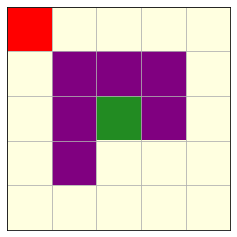

```python
maze = Maze.create(['o....',
                    '.###.',
                    '.#*#.',
                    '.#...',
                    '.....'])

maze.plot()
```

## DFS en BFS

Met een zoekalgoritme willen we op zoek gaan naar een pad in de zoekboom waardoor je de goal kan bereiken. Meestal zal je de volledige zoekboom niet expliciet berekenen. Voor diepte-eerst en breedte-eerst doen we dit inderdaad ook niet.

We moeten wel een pad kunnen voorstellen van startpositie naar doel. Een node in de zoekboom komt immers overeen met een pad. Maar omdat onze toestand het pad al bevat, komt elke node in de zoekboom ook overeen met een toestand. In de pseudocode van DFS en BFS kunnen we 'path' daarom eenvoudigweg vervangen door 'state', en de 'root' van onze zoekboom komt dus overeen met de 'initial state'.

We vertalen de pseudocode van beide algoritmen naar Python code en passen die toe op ons `maze` probleem.

### Diepte-eerst

De pseudocode van DFS uit de cursus:

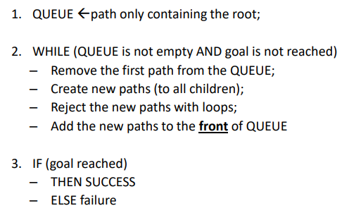

Die pseudocode kunnen we nu makkelijk vertalen naar Python code, als we 'path' vervangen door de overeenkomstige `MazeState` objecten, zoals we hierboven hebben uitgelegd:

```python
# 1. queue <- path only containing the root
queue = [InitialMazeState(maze)]

# 2. while (queue is not empty and goal is not reached)
goal_is_reached = False
while queue and not goal_is_reached:

    # remove the first path from the queue
    first_state = queue.pop(0)

    # create new paths (to all children)
    # reject the new paths with loops (which is also done by method calculate_moves)
    new_states = [first_state.apply_move(move) for move in first_state.calculate_moves()]

    # update goal_is_reached
    for state in new_states:
        if state.is_goal():
            goal_is_reached = True
            break

    # add the new paths to the FRONT of the queue
    queue = new_states + queue

# 3. if (goal reached) then success else failure
print("SUCCES" if goal_is_reached else "FAILURE")
```

```
SUCCES
```

We zien dat DFS het LIFO principe toepast: **last in first out!**

Omdat we een `break` gebruiken in de lus die checkt of één van de `new_states` de eindtoestand is, zal `state` onze oplossing bevatten (als er een oplossing is tenminste):

```python
state.full_path
```

```
[(2, 2), (3, 2), (3, 3), (3, 4), (2, 4), (1, 4), (0, 4), (0, 3), (0, 2), (0, 1), (0, 0)]
```

We kunnen het doorlopen van het pad nu ook 'live' gaan plotten:

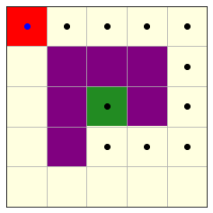

```python
state.dynamic_plot()
```

### Breedte-eerst

De pseudocode van BFS uit de cursus:

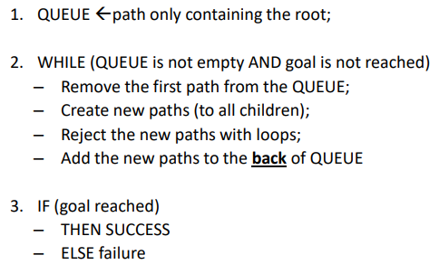

Het algoritme is hetzelfde als dat van DFS, alleen moeten we nieuwe paden *achteraan* de queue toevoegen i.p.v. vooraan, want BFS past het FIFO principe toe: **first in first out!**

```python
# 1. queue <- path only containing the root
queue = [InitialMazeState(maze)]

# 2. while (queue is not empty and goal is not reached)
goal_is_reached = False
while queue and not goal_is_reached:

    # remove the first path from the queue
    first_state = queue.pop(0)

    # create new paths (to all children)
    # reject the new paths with loops (which is also done by method calculate_moves)
    new_states = [first_state.apply_move(move) for move in first_state.calculate_moves()]

    # update goal_is_reached
    for state in new_states:
        if state.is_goal():
            goal_is_reached = True
            break

    # add the new paths to the BACK of the queue
    queue = queue + new_states

# 3. if (goal reached) then success else failure
print("SUCCES" if goal_is_reached else "FAILURE")
```

```
SUCCES
```

We hebben dus de code van DFS kunnen kopiëren, en enkel het volgende lijntje code moesten we aanpassen:

```
# add the new paths to the BACK of the queue
queue = queue + new_states
```

We krijgen echter een totaal andere oplossing, want in tegenstelling tot DFS, **vindt BFS het kortste pad!**

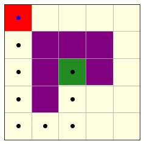

```python
state.dynamic_plot()
```

## Opdrachten

### Opdracht 1

Voer DFS en BFS opnieuw uit maar print nu na elke iteratie de laatste positie van de paden in de queue uit. De laatste positie van een pad is het vakje waar men staat in die toestand.

Welk algoritme is het snelst? Welk algoritme heeft het minst geheugen nodig?

DFS:

```python
# 1. queue <- path only containing the root
queue = [InitialMazeState(maze)]

# 2. while (queue is not empty and goal is not reached)
goal_is_reached = False
while queue and not goal_is_reached:

    # print queue
    print([state.position for state in queue])

    # remove the first path from the queue
    first_state = queue.pop(0)

    # create new paths (to all children)
    # reject the new paths with loops (which is also done by method calculate_moves)
    new_states = [first_state.apply_move(move) for move in first_state.calculate_moves()]

    # update goal_is_reached
    for state in new_states:
        if state.is_goal():
            goal_is_reached = True
            break

    # add the new paths to the FRONT of the queue
    queue = new_states + queue

# 3. if (goal reached) then success else failure
print("SUCCES" if goal_is_reached else "FAILURE")
```

```
[(2, 2)]
[(3, 2)]
[(3, 3), (4, 2)]
[(3, 4), (4, 3), (4, 2)]
[(2, 4), (4, 4), (4, 3), (4, 2)]
[(1, 4), (4, 4), (4, 3), (4, 2)]
[(0, 4), (4, 4), (4, 3), (4, 2)]
[(0, 3), (4, 4), (4, 3), (4, 2)]
[(0, 2), (4, 4), (4, 3), (4, 2)]
[(0, 1), (4, 4), (4, 3), (4, 2)]
SUCCES
```

BFS:

```python
# 1. queue <- path only containing the root
queue = [InitialMazeState(maze)]

# 2. while (queue is not empty and goal is not reached)
goal_is_reached = False
while queue and not goal_is_reached:

    # print queue
    print([state.position for state in queue])

    # remove the first path from the queue
    first_state = queue.pop(0)

    # create new paths (to all children)
    # reject the new paths with loops (which is also done by method calculate_moves)
    new_states = [first_state.apply_move(move) for move in first_state.calculate_moves()]

    # update goal_is_reached
    for state in new_states:
        if state.is_goal():
            goal_is_reached = True
            break

    # add the new paths to the BACK of the queue
    queue = queue + new_states

# 3. if (goal reached) then success else failure
print("SUCCES" if goal_is_reached else "FAILURE")
```

```
[(2, 2)]
[(3, 2)]
[(3, 3), (4, 2)]
[(4, 2), (3, 4), (4, 3)]
[(3, 4), (4, 3), (4, 1), (4, 3)]
[(4, 3), (4, 1), (4, 3), (2, 4), (4, 4)]
[(4, 1), (4, 3), (2, 4), (4, 4), (4, 2), (4, 4)]
[(4, 3), (2, 4), (4, 4), (4, 2), (4, 4), (4, 0)]
[(2, 4), (4, 4), (4, 2), (4, 4), (4, 0), (4, 4), (3, 3)]
[(4, 4), (4, 2), (4, 4), (4, 0), (4, 4), (3, 3), (1, 4)]
[(4, 2), (4, 4), (4, 0), (4, 4), (3, 3), (1, 4), (4, 3)]
[(4, 4), (4, 0), (4, 4), (3, 3), (1, 4), (4, 3), (4, 1)]
[(4, 0), (4, 4), (3, 3), (1, 4), (4, 3), (4, 1), (3, 4)]
[(4, 4), (3, 3), (1, 4), (4, 3), (4, 1), (3, 4), (3, 0)]
[(3, 3), (1, 4), (4, 3), (4, 1), (3, 4), (3, 0), (3, 4)]
[(1, 4), (4, 3), (4, 1), (3, 4), (3, 0), (3, 4), (3, 4)]
[(4, 3), (4, 1), (3, 4), (3, 0), (3, 4), (3, 4), (0, 4)]
[(4, 1), (3, 4), (3, 0), (3, 4), (3, 4), (0, 4), (4, 2)]
[(3, 4), (3, 0), (3, 4), (3, 4), (0, 4), (4, 2), (4, 0)]
[(3, 0), (3, 4), (3, 4), (0, 4), (4, 2), (4, 0), (2, 4)]
[(3, 4), (3, 4), (0, 4), (4, 2), (4, 0), (2, 4), (2, 0)]
[(3, 4), (0, 4), (4, 2), (4, 0), (2, 4), (2, 0), (3, 3), (2, 4)]
[(0, 4), (4, 2), (4, 0), (2, 4), (2, 0), (3, 3), (2, 4), (2, 4), (4, 4)]
[(4, 2), (4, 0), (2, 4), (2, 0), (3, 3), (2, 4), (2, 4), (4, 4), (0, 3)]
[(4, 0), (2, 4), (2, 0), (3, 3), (2, 4), (2, 4), (4, 4), (0, 3), (4, 1)]
[(2, 4), (2, 0), (3, 3), (2, 4), (2, 4), (4, 4), (0, 3), (4, 1), (3, 0)]
[(2, 0), (3, 3), (2, 4), (2, 4), (4, 4), (0, 3), (4, 1), (3, 0), (1, 4)]
[(3, 3), (2, 4), (2, 4), (4, 4), (0, 3), (4, 1), (3, 0), (1, 4), (1, 0)]
[(2, 4), (2, 4), (4, 4), (0, 3), (4, 1), (3, 0), (1, 4), (1, 0)]
[(2, 4), (4, 4), (0, 3), (4, 1), (3, 0), (1, 4), (1, 0), (1, 4)]
[(4, 4), (0, 3), (4, 1), (3, 0), (1, 4), (1, 0), (1, 4), (1, 4)]
[(0, 3), (4, 1), (3, 0), (1, 4), (1, 0), (1, 4), (1, 4)]
[(4, 1), (3, 0), (1, 4), (1, 0), (1, 4), (1, 4), (0, 2)]
[(3, 0), (1, 4), (1, 0), (1, 4), (1, 4), (0, 2), (4, 0)]
[(1, 4), (1, 0), (1, 4), (1, 4), (0, 2), (4, 0), (2, 0)]
[(1, 0), (1, 4), (1, 4), (0, 2), (4, 0), (2, 0), (0, 4)]
SUCCES
```

Het is duidelijk dat in dit geval DFS minder rekentijd nodig heeft om een oplossing te vinden en ook minder geheugen. DFS vindt wel niet het kortste pad...

### Opdracht 2

Pas DFS en BFS toe op de doolhof uit de figuur aan het begin van de notebook.

Wat is nu het snelste algoritme? Welk heeft het minste geheugen nodig? En welk vindt het kortste pad?

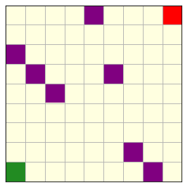

```python
maze2 = Maze.create(['....#...o',
                     '.........',
                     '#........',
                     '.#...#...',
                     '..#......',
                     '.........',
                     '.........',
                     '......#..',
                     '*......#.'])
maze2.plot()
```

We gaan de rekentijd chronometreren met functie `time` uit de gelijknamige module:

```python
from time import time
```

```python
start_time = time()
x = 1
for _ in range(1000000):
    x += 1
elapsed_time = time() - start_time
elapsed_time
```

```
0.11530375480651855
```

Het uitprinten van de queue wordt in dit geval lastig. Daarom gaan we de lengte van de queue bijhouden in een list. De maximale lengte zal ons een idee geven van het geheugengebruik.

DFS:

```python
# start time
starttime = time()

# 1. queue <- path only containing the root
queue = [InitialMazeState(maze2)]

# initialize length queue
length_queue = [1]

# 2. while (queue is not empty and goal is not reached)
goal_is_reached = False
while queue and not goal_is_reached:

    # length queue
    length_queue.append(len(queue))

    # remove the first path from the queue
    first_state = queue.pop(0)

    # create new paths (to all children)
    # reject the new paths with loops (which is also done by method calculate_moves)
    new_states = [first_state.apply_move(move) for move in first_state.calculate_moves()]

    # update goal_is_reached
    for state in new_states:
        if state.is_goal():
            goal_is_reached = True
            break

    # add the new paths to the FRONT of the queue
    queue = new_states + queue

# 3. if (goal reached) then success else failure
print("SUCCES" if goal_is_reached else "FAILURE")

# print elapsed time
print("Elapsed time:", time() - starttime, 'seconds')

# print maximum length of queue
print('Maximum length of queue:', max(length_queue))
```

```
SUCCES
Elapsed time: 0.00592350959777832 seconds
Maximum length of queue: 48
```

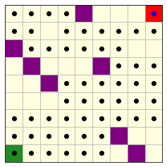

```python
state.dynamic_plot(0.5)
```

BFS:

```python
# start time
starttime = time()

# 1. queue <- path only containing the root
queue = [InitialMazeState(maze2)]

# initialize length queue
length_queue = [1]

# 2. while (queue is not empty and goal is not reached)
goal_is_reached = False
while queue and not goal_is_reached:

    # length queue
    length_queue.append(len(queue))

    # remove the first path from the queue
    first_state = queue.pop(0)

    # create new paths (to all children)
    # reject the new paths with loops (which is also done by method calculate_moves)
    new_states = [first_state.apply_move(move) for move in first_state.calculate_moves()]

    # update goal_is_reached
    for state in new_states:
        if state.is_goal():
            goal_is_reached = True
            break

    # add the new paths to the BACK of the queue
    queue = queue + new_states

# 3. if (goal reached) then success else failure
print("SUCCES" if goal_is_reached else "FAILURE")

# print elapsed time
print("Elapsted time:", time() - starttime, 'seconds')

# print maximum length of queue
print('Maximum length of queue:', max(length_queue))
```

```
SUCCES
Elapsted time: 121.27994179725647 seconds
Maximum length of queue: 131094
```

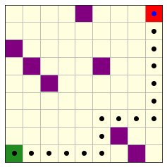

```python
state.dynamic_plot()
```

Ook hier is DFS (veel) sneller en gebruikt het (veel) minder geheugen, maar het vindt zeker en vast niet het kortste pad, terwijl BFS dat uiteraard wel doet. We hebben duidelijk nood aan "intelligentere" algoritmes...

### Opdracht 3

Al dat gekopieer is natuurlijk niet volgens de regels van de kunst van het programmeren. Kan je de code voor DFS en BFS in één functie stoppen?

Test je functie uit op het `maze` voorbeeldje.

```python
def dfs_bfs(state, method):
# state is State object defining the initial state
# method is 'dfs' or 'bfs'

    # start time
    starttime = time()

    # 1. queue <- path only containing the root
    queue = [state]

    # initialize length queue
    length_queue = [len(queue)]

    # 2. while (queue is not empty and goal is not reached)
    goal_is_reached = state.is_goal()
    while queue and not goal_is_reached:

        # length queue
        length_queue.append(len(queue))

        # remove the first path from the queue
        first_state = queue.pop(0)

        # create new paths (to all children)
        # reject the new paths with loops (which is also done by method calculate_moves)
        new_states = [first_state.apply_move(move) for move in first_state.calculate_moves()]

        # update goal_is_reached
        for state in new_states:
            if state.is_goal():
                goal_is_reached = True
                break

        # if method is DFS: add the new paths to the FRONT of the queue
        if method.lower() == 'dfs':
            queue = new_states + queue
        # if method is BFS: add the new paths to the BACK of the queue
        elif method.lower() == 'bfs':
            queue = queue + new_states

    # 3. if (goal reached) then success else failure
    print("SUCCES" if goal_is_reached else "FAILURE")

    # print elapsed time
    print("Elapsted time:", time() - starttime, 'seconds')

    # print maximum length of queue
    print('Maximum length of queue:', max(length_queue))

    # return goal state if goal is reached and None otherwise
    return state if goal_is_reached else None
```

Bemerk dat we een initiële state opgeven en geen `Maze` object, omdat we een generieke functie willen die onafhankelijk is van het doolhofprobleem!

```
SUCCES
Elapsted time: 0.0011391639709472656 seconds
Maximum length of queue: 4
```

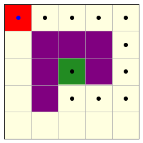

```python
solution = dfs_bfs(InitialMazeState(maze), 'dfs')
if solution:
    solution.plot()
```

```
SUCCES
Elapsted time: 0.002651691436767578 seconds
Maximum length of queue: 9
```

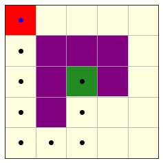

```python
solution = dfs_bfs(InitialMazeState(maze), 'bfs')
if solution:
    solution.plot()
```

### Opdracht 4

Maak onderstaand doolhof aan en pas DFS en BFS toe om een oplossing te vinden:

```
['......o',
 '.#####.',
 '.......',
 '.#####.',
 '.......',
 '.#####.',
 '*......']
```

Vergelijk opnieuw snelheid en geheugen, en check of het kortste pad wordt gevonden.

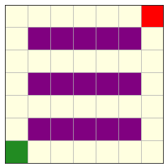

```python
maze3 = Maze.create(['......o',
                     '.#####.',
                     '.......',
                     '.#####.',
                     '.......',
                     '.#####.',
                     '*......'])
maze3.plot()
```

```
SUCCES
Elapsted time: 0.002966642379760742 seconds
Maximum length of queue: 6
```

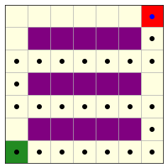

```python
dfs_bfs(InitialMazeState(maze3), 'dfs').plot()
```

```
SUCCES
Elapsted time: 0.004706621170043945 seconds
Maximum length of queue: 9
```

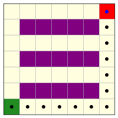

```python
dfs_bfs(InitialMazeState(maze3), 'bfs').plot()
```

### Opdracht 5

Neem hetzelfde doolhof als in opdracht 4, en pas opnieuw DFS en BFS toe, maar wijzig nu de volgorde van de production rules naar "onder, boven, rechts, links" in plaats van "links, rechts, boven, onder". Krijg je nog steeds dezelfde oplossing? Heeft het wijzigen van die volgorde invloed op rekentijd en geheugengebruik?

Tip: Klasse `MazeState` en subklasse `InitialMazeState` bevatten een methode `set_production_rules` waarmee je de volgorde makkelijk kan wijzigen. In dit geval:

```
maze_state_object.set_production_rules(Down, Up, Right, Left)
```

```python
# initial state definiëren en de volgorde van de production rules wijzigen
ini_state = InitialMazeState(maze3)
ini_state.set_production_rules(Down, Up, Right, Left)
```

```
SUCCES
Elapsted time: 0.0007543563842773438 seconds
Maximum length of queue: 4
```

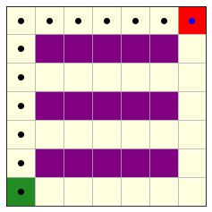

```python
# dfs
dfs_bfs(ini_state, 'dfs').plot()
```

```
SUCCES
Elapsted time: 0.004057168960571289 seconds
Maximum length of queue: 9
```

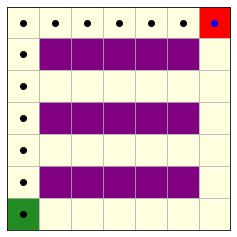

```python
# bfs
dfs_bfs(ini_state, 'bfs').plot()
```

Het is duidelijk dat het wijzigen van de volgorde waarin de productieregels worden toegepast tot andere oplossingen leidt.

### Opdracht 6

Verzin nu zelf enkele doolhofproblemen en pas er DFS en BFS op toe. Speel ook met de volgorde van de production rules. Bestudeer de bekomen oplossingen door de inhoud van de queue na elke iteratie te analyseren. Op het examen moet je in staat zijn om zelf de oplossing van die algoritmes te geven!

### Opdracht 7

Neem opnieuw het spel [ganzenbord](https://nl.wikipedia.org/wiki/Ganzenbord) dat we in de vorige notebook m.b.v. state-space representation hebben gemodelleerd. Pas hier nu ook DFS en BFS toe om een oplossing te vinden, d.i. een opeenvolging van worpen om van start tot einde te komen. Om de rekentijd bij BFS te beperken zullen we 33 ipv 63 vakjes nemen.

In het echte ganzenbordspel is het uiteraard mogelijk om terecht te komen op een eerder vakje, maar omdat we oneindige lussen willen vermijden, sluiten we die optie uit. In methode `GooseBoardState.is_valid` moeten we daarom ook nog checken of een nieuwe positie al dan niet tot het afgelegde pad behoort. Als dat zo is, dan is de zet niet geldig.

De toestand hebben we gedefiniëerd aan de hand van de positie, dit is het vakje waar de pion staat, en de configuratie van het bord, hier start- en eindvakje en de vakjes met een put of valkuil waarop de pion terug naar start moet. (We houden het hier eenvoudig, maar uiteraard kan je nog andere speciale vakjes definiëren). We moeten ook nog het pad bijhouden.

```python
# position is hier een integer die het huidige vakje aangeeft
class Position:

    def __init__(self, number):
        self.number = number

    def __eq__(self, other):
        return self.number == other.number

    def __repr__(self):
        return str(self.number)
```

```python
# path is nodig om de nodes in de zoekboom voor te stellen
import numpy as np

class Path:

    def __init__(self, *positions):
        self.positions = positions

    @property
    def length(self):
        return len(self.positions)

    @property
    def numbers(self):
        return np.array([position.number for position in self.positions])

    def contains(self, position):
        return position in self.positions

    def add(self, position):
        return Path(*self.positions, position)

    def __repr__(self):
        positions = ", ".join([str(position) for position in self.positions])
        return f"[{positions}]"
```

```python
# Het ganzenbord met putten die een pion terug naar start sturen
class GooseGameBoard:

    def __init__(self, pitfalls=[], start=1, goal=63):
        self.start = start
        self.goal = goal
        self.pitfalls = pitfalls

    def get_start(self):
        return Position(self.start)

    def get_goal(self):
        return Position(self.goal)

    def is_valid(self, position):
        # checkt of een positie geldig is: moet binnen de range van start en goal liggen
        return self.start <= position.number <= self.goal

    def to_dict(self):
        # omzetten naar dictionary kan handig zijn
        # een Python dictionary is equivalent met een Java HashMap
        return dict(start=self.start, goal=self.goal, putten=self.pitfalls)

    def __repr__(self):
        return str(self.to_dict())
```

De production rules zijn alle mogelijke uitkomsten na het werpen van de 2 dobbelstenen. Voor de eenvoud gebruiken we hier 1 dobbelsteen, dus zijn er 6 regels: 1, 2, 3, 4, 5 en 6 vakjes vooruit gaan.

```python
# klasse Throw moet erven van superklasse Move

class Throw(Move):

    def __init__(self, state, steps):
        super().__init__(state)
        self.steps = steps

    def new_position(self):
        return Position(self.state.position.number + self.steps)

    def __repr__(self):
        return "gooi " + str(self.steps)
```

```python
# Ook hier definiëren we een klasse voor elke worp
class Een(Throw):
    def __init__(self, state):
        super().__init__(state, 1)
class Twee(Throw):
    def __init__(self, state):
        super().__init__(state, 2)
class Drie(Throw):
    def __init__(self, state):
        super().__init__(state, 3)
class Vier(Throw):
    def __init__(self, state):
        super().__init__(state, 4)
class Vijf(Throw):
    def __init__(self, state):
        super().__init__(state, 5)
class Zes(Throw):
    def __init__(self, state):
        super().__init__(state, 6)
```

Tenslotte moeten we nog een klasse definiëren voor de toestand. We breiden de `is_valid` methode uit met een extra check die nagaat of de nieuwe positie al dan niet tot het afgelegde pad behoort. We voorzien ook de mogelijkheid om de production rules te wijzigen.

```python
# klasse GooseGameState moet erven van State
class GooseGameState(State):

    def __init__(self, board, position, path):
        self.board = board
        self.position = position
        self.path = path
        self.rules = [Een(self), Twee(self), Drie(self), Vier(self), Vijf(self), Zes(self)]

    @property
    def full_path(self):
        return self.path.add(self.position)

    def set_production_rules(self, *Moves):
        # Moves is input lijst met Throw klassen
        self.rules = [Move(self) for Move in Moves]

    def calculate_moves(self):
        if self.is_goal():
            return []  # geen moves meer als we in de eindtoestand zijn
        return [move for move in self.rules if self.is_valid(move)]

    def is_valid(self, move):
        new_position = self.new_position(move)
        return (self.board.is_valid(new_position) and
                not self.full_path.contains(new_position))  # nieuwe positie mag geen deel uitmaken van het pad!

    def new_position(self, move):
        new_position = move.new_position()
        if new_position.number in self.board.pitfalls:
            return self.board.get_start()  # terug naar start bij put
        if new_position.number > self.board.goal:
            return self.position  # blijven staan als je op 't einde te veel gooit
        return new_position

    def apply_move(self, move):
        new_state = GooseGameState(self.board, self.new_position(move), self.full_path)  # nieuwe toestand
        Moves = [type(rule) for rule in self.rules]
        new_state.set_production_rules(*Moves)
        return new_state

    def is_goal(self):
        return self.board.get_goal() == self.position

    def to_dict(self):
        state = self.board.to_dict()
        state["vakje"] = self.position
        state["vorige"] = self.path
        return state

    def __repr__(self):
        return str(self.to_dict())
```

```python
# klasse voor de initiële toestand
class InitialGooseGameState(GooseGameState):
    def __init__(self, board):
        super().__init__(board, board.get_start(), Path())
```

We passen nu DFS en BFS toe:

```python
goal = 33
bord = GooseGameBoard(start=1, goal=goal, pitfalls=list(range(10, goal, 10)))
bord
```

```
{'start': 1, 'goal': 33, 'putten': [10, 20, 30]}
```

```python
ini_state = InitialGooseGameState(bord)
ini_state
```

```
{'start': 1, 'goal': 33, 'putten': [10, 20, 30], 'vakje': 1, 'vorige': []}
```

```python
solution = dfs_bfs(ini_state, 'dfs')
```

```
SUCCES
Elapsted time: 0.00785374641418457 seconds
Maximum length of queue: 106
```

```python
solution.full_path
```

```
[1, 2, 3, 4, 5, 6, 7, 8, 9, 11, 12, 13, 14, 15, 16, 17, 18, 19, 21, 22, 23, 24, 25, 26, 27, 33]
```

Omdat de production rules met het werpen van één starten, gaan we hier dus telkens één vakje vooruit, tenzij voor een put, waar we 2 vakjes nemen om over de put te springen, en op het einde, waar we eindigen met het gooien van een zes. Begrijp je ook waarom we zo eindigen?

En nu BFS:

```python
solution = dfs_bfs(ini_state, 'bfs')
```

```
SUCCES
Elapsted time: 0.5835137367248535 seconds
Maximum length of queue: 12288
```

```python
solution.full_path
```

```
[1, 3, 9, 15, 21, 27, 33]
```

BFS vindt uiteraard een oplossing met het minst aantal worpen.

Laten we eens de production rules omdraaien:

```python
ini_state.rules.reverse()
solution = dfs_bfs(ini_state, 'dfs')
```

```
SUCCES
Elapsted time: 0.002590656280517578 seconds
Maximum length of queue: 23
```

```python
solution.full_path
```

```
[1, 7, 13, 19, 25, 31, 33]
```

En wat geeft dat bij BFS?

```python
solution = dfs_bfs(ini_state, 'bfs')
```

```
SUCCES
Elapsted time: 0.18123698234558105 seconds
Maximum length of queue: 4785
```

```python
solution.full_path
```

```
[1, 7, 13, 19, 25, 31, 33]
```

Merk ook op dat het omdraaien van de production rules ervoor zorgt dat we bij zowel DFS als BFS sneller een oplossing vinden en ook minder geheugen nodig hebben. Waarom is dat?

### Opdracht 8

Probeer nu ook het ganzenbordprobleem op te lossen met 63 vakjes. Hoe lang duurt het om een oplossing te vinden met DFS? En hoe lang doet BFS erover? Kan je dat verklaren?

Het antwoord op deze vraag wordt in het volgende topic uitvoerig behandeld. In dat topic zullen we immers de complexiteit van DFS en BFS op vlak van rekentijd en geheugen inschatten.